# Hao-HW2

Bruce Hao

September 7, 2016

Setup.

```r
library(VennDiagram)
```

**2.6**

```r
combinations = expand.grid(seq(1,6), seq(1,6))
combinations$Total = combinations$Var1 + combinations$Var2
nrow(combinations[combinations$Total==5, ])
```

```
## [1] 4
```

1. 0
2. 4/36 = 11.11%
3. 1/36 = 2.78%

**2.8**

1. No, disjoint outcomes are mutually exclusive and have probabilities that sum to 1.

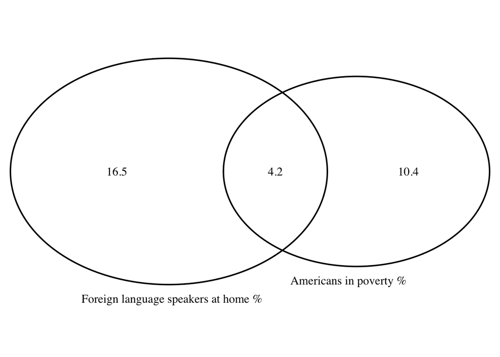

```
## (polygon[GRID.polygon.1], polygon[GRID.polygon.2], polygon[GRID.polygon.3], polygon[GRID.polygon.4], text[GRID.text.5], text[GRID.text.6], text[GRID.text.7], text[GRID.text.8], text[GRID.text.9])
```

```r
draw.pairwise.venn(area1 = 14.6, area2 = 20.7, cross.area = 4.2,
                   category = c('Americans in poverty %', 'Foreign language speakers at home %'),
                   cat.pos = c(3, -1))
```

3. 10.4%
4. 16.5 + 4.2 + 10.4 = 31.1%
5. 100 - 31.1 = 68.9%
6. No, the probability of being below the poverty line is 14.6% for all Americans, but the probability of being below the poverty line given being a foreign language speaker at home is 4.2/20.7 = 20.29%

**2.20**

1. (114 + 108) / 408 = 54.41%
2. 78 / 114 = 68.42%
3. 19 / 54 = 35.19%; 11 / 36 = 30.56%
4. No, the color of the male’s eyes affects the probability of having a partner with certain eye color.

**2.30**

1. 28/95 * 59/94 = 18.50%
2. 67/95 * 28/94 = 21.01%
3. 67/95 * 28/95 = 20.79%
4. When the sample size is a small fraction of the population, observations are nearly independent even when sampling without replacement.

**2.38**

1. 0 * 0.54 + 25 * 0.34 + 35 * 0.12 = $12.7 average revenue per passenger; 0.54*(0 - 12.7)^2 + 0.34*(25 - 12.7)^2 + 0.12*(35 - 12.7)^2 = $198.21 variance; 198.21^0.5 = $14.08 standard deviation
2. $12.7 * 120 = $1,524 revenue per flight; ($198.21 * 120)^0.5 = $154 standard deviation

**2.44**

```
##           M    F Total
## <$50K  32.8 29.4  62.2
## >=$50K 26.2 11.6  37.8
## Total  59.0 41.0 100.0
```